# midterm

```r
border <- read.csv("C:/Users/27753/Desktop/PM566/Border.csv")
```

```r
library(tidyverse)
library(lubridate)
library(stringr)
# --- Data Cleaning & Wrangling ---
# Check and count missing values per variable
border %>%
  summarise(across(everything(), ~ sum(is.na(.)), .names = "na_{col}"))
```

```
  na_Port.Name na_State na_Port.Code na_Border na_Date na_Measure na_Value
1            0        0            0         0       0          0        0
  na_Latitude na_Longitude na_Point
1           4            4        0
```

```r
# 1. Handle missing values
border <- border %>%
  drop_na(State, Latitude, Longitude, Point)

# 2. Clean the 'Value' column (remove commas and convert to numeric)
border <- border %>%
  mutate(Value = as.numeric(gsub(",", "", Value)))

# 3. Convert 'Date' column (e.g., "Aug 2025") to proper date and extract Year/Month
border <- border %>%
  mutate(
    month = str_extract(Date, "^[A-Za-z]+"),
    Year = str_extract(Date, "\\d{4}"),
    Year = as.numeric(Year),
    # change the month variable from string to integer
    month = str_to_title(month),
    temp_date = paste(month, Year),
    temp_date = my(temp_date),
    month = month(temp_date)
  ) %>%
  select(-temp_date)
border
```

[output not shown]

[output cut: 24988 more lines]

After the clean and prep, there is no values in the table so the analysis could be more precise. The data in the “Value” variable all turn to numeric so the next step we may be can analysis such question like “find the maximum 10 or minimum 10 place in a certain year”, The “Date” variable also separate into two variable” month” and “year”, which can help us better locate when is time of the certain data we want to search.

3.Exploratory Analysis:step checking the data and cleaning the data is down on step 2

```r
library(tidyverse)
library(knitr)
library(kableExtra)
library(scales)
# 1. dataset characteristics and variables included
colnames(border)
```

```
 [1] "Port.Name" "State"     "Port.Code" "Border"    "Date"      "Measure"
 [7] "Value"     "Latitude"  "Longitude" "Point"     "month"     "Year"
```

```r
cat("Number of rows:", nrow(border), "\n")
```

```
Number of rows: 403853
```

```r
cat("Number of columns:", ncol(border), "\n")
```

```
Number of columns: 12
```

```r
# --- Summary by Year and Border Type ---
yearly_summary <- border %>%
  group_by(Year, Border) %>%
  summarise(
    Total_Value = sum(Value, na.rm = TRUE),
    Mean_Value = mean(Value, na.rm = TRUE),
    Median_Value = median(Value, na.rm = TRUE),
    SD_Value = sd(Value, na.rm = TRUE),
    .groups = "drop"
  )

# --- Display as a publication-quality table ---
# yearly_summary %>%
#   mutate(
#     Total_Value = comma(Total_Value),
#     Mean_Value = round(Mean_Value, 2),
#     Median_Value = round(Median_Value, 2),
#     SD_Value = round(SD_Value, 2)
#   ) %>%
#   kable(
#     caption = "Summary Statistics of Cross-Border Traffic by Year and Border Type",
#     align = "c",
#     format = "html"
#   ) %>%
#   kable_styling(full_width = FALSE, bootstrap_options = c("hover", "condensed", "striped"))
```

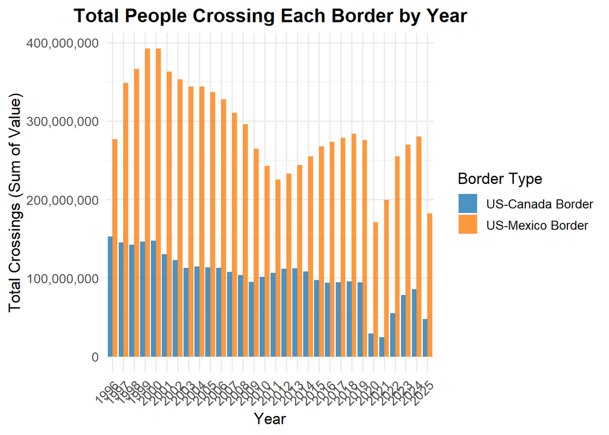

```r
library(tidyverse)
library(scales)
library(knitr)
library(kableExtra)

# --- 1. Aggregate total crossings per year and border ---
yearly_border_people <- border %>%
  group_by(Year, Border) %>%
  summarise(Total_People = sum(Value, na.rm = TRUE), .groups = "drop") %>%
  arrange(Year)

# --- 2. Histogram (bar chart) by border ---
ggplot(yearly_border_people, aes(x = factor(Year), y = Total_People, fill = Border)) +
  geom_col(position = "dodge", alpha = 0.8) +
  scale_y_continuous(labels = comma) +
  scale_fill_manual(values = c("US-Canada Border" = "#1f77b4", "US-Mexico Border" = "#ff7f0e")) +
  labs(
    title = "Total People Crossing Each Border by Year",
    x = "Year",
    y = "Total Crossings (Sum of Value)",
    fill = "Border Type"
  ) +
  theme_minimal(base_size = 13) +
  theme(
    plot.title = element_text(face = "bold", hjust = 0.5),
    axis.text.x = element_text(angle = 45, hjust = 1)
  )
```

```r
# --- 3. Show the same data in a clean table ---
yearly_border_people %>%
  mutate(Total_People = comma(Total_People)) %>%
  pivot_wider(names_from = Border, values_from = Total_People) %>%
  kable(
    caption = "Total People Crossing Each Border by Year",
    align = "c",
    format = "html"
  ) %>%
 kable_styling(full_width = FALSE, bootstrap_options = c("hover", "striped", "condensed"))
```

Total People Crossing Each Border by Year

| Year | US-Canada Border | US-Mexico Border |
| --- | --- | --- |
| 1996 | 153,038,903 | 276,751,448 |
| 1997 | 145,512,710 | 348,661,488 |
| 1998 | 142,291,790 | 366,296,614 |
| 1999 | 146,497,328 | 391,959,396 |
| 2000 | 147,789,673 | 392,231,869 |
| 2001 | 130,092,391 | 362,991,511 |
| 2002 | 122,832,695 | 352,870,123 |
| 2003 | 112,738,414 | 343,654,239 |
| 2004 | 114,695,622 | 343,524,676 |
| 2005 | 113,243,701 | 336,990,567 |
| 2006 | 112,707,996 | 327,588,026 |
| 2007 | 107,491,421 | 310,095,754 |
| 2008 | 103,980,803 | 295,921,230 |
| 2009 | 95,001,517 | 264,450,245 |
| 2010 | 101,469,642 | 242,776,894 |
| 2011 | 106,684,911 | 225,541,089 |
| 2012 | 111,504,252 | 232,999,664 |
| 2013 | 112,236,211 | 243,982,227 |
| 2014 | 108,567,839 | 254,746,277 |
| 2015 | 97,556,562 | 267,663,436 |
| 2016 | 93,951,778 | 273,532,405 |
| 2017 | 94,268,274 | 278,703,002 |
| 2018 | 95,413,960 | 283,743,197 |
| 2019 | 94,661,870 | 275,538,145 |
| 2020 | 29,507,038 | 171,024,678 |
| 2021 | 24,617,052 | 199,542,060 |
| 2022 | 55,389,412 | 255,092,099 |
| 2023 | 78,044,169 | 269,845,861 |
| 2024 | 86,084,295 | 280,439,163 |
| 2025 | 47,769,408 | 182,226,641 |

It can be seen that the number of people per year has up and down for both two borders,which could be caused by certain policy. The number of people crossing the US-Mexico Border is much higher than the US-Canada Border, which may infer that people tend cross border from Mexico. I also want to find the relationship between measure and value, the plot will show how many type in “Measure”, and show the num of people who use this measure at year 2025

```r
library(tidyverse)
library(scales)

# --- 1. Count how many unique Measure types ---
num_measure_types <- border %>%
  distinct(Measure) %>%
  nrow()

cat("Number of unique Measure types:", num_measure_types, "\n")
```

```
Number of unique Measure types: 12
```

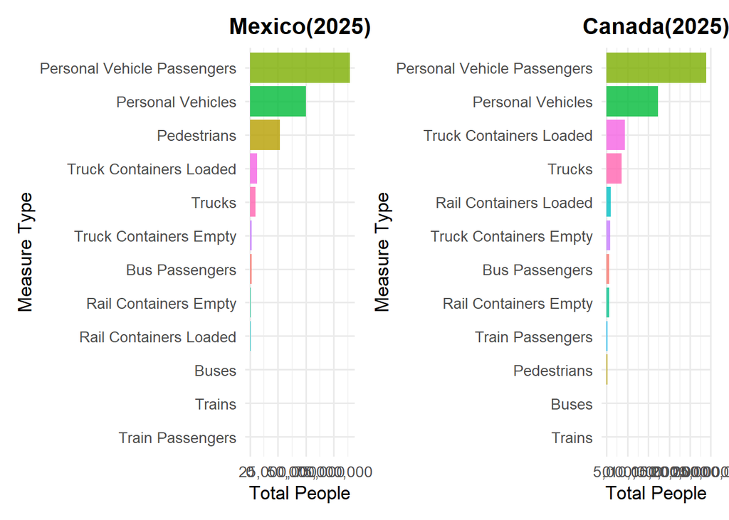

```r
# --- 2. Filter for year 2025 and summarize totals by Measure and Border ---
measure_2025 <- border %>%
  filter(Year == 2025) %>%
  group_by(Border, Measure) %>%
  summarise(Total_People = sum(Value, na.rm = TRUE), .groups = "drop") %>%
  arrange(Border, desc(Total_People))

# --- 3. make plot
mexico_plot <- measure_2025 %>%
  filter(Border == "US-Mexico Border") %>%
  ggplot(aes(x = reorder(Measure, Total_People), y = Total_People, fill = Measure)) +
  geom_col(alpha = 0.8) +
  scale_y_continuous(labels = comma) +
  coord_flip() +
  labs(
    title = "Mexico(2025)",
    x = "Measure Type",
    y = "Total People"
  ) +
  theme_minimal(base_size = 13) +
  theme(
    plot.title = element_text(face = "bold", hjust = 0.5),
    legend.position = "none"
  )


canada_plot <- measure_2025 %>%
  filter(Border == "US-Canada Border") %>%
  ggplot(aes(x = reorder(Measure, Total_People), y = Total_People, fill = Measure)) +
  geom_col(alpha = 0.8) +
  scale_y_continuous(labels = comma) +
  coord_flip() +
  labs(
    title = "Canada(2025)",
    x = "Measure Type",
    y = "Total People"
  ) +
  theme_minimal(base_size = 13) +
  theme(
    plot.title = element_text(face = "bold", hjust = 0.5),
    legend.position = "none"
  )
library(patchwork)
mexico_plot + canada_plot
```

It can been seen that there are 12 unique types of transportation to cross the board, and the plot could show that personal vehicles passengers counts for the most in both two board, but from the third most type, the two board start to look different, this may due to different development of local transportation and that need further research.Governors could make inspects works relevant to that number of each type. More analysis about the relationship, it should go to the Preliminary Results part. 4.Preliminary Results: use the lattitude and longtitude, we can visualize the frequency of value on the map to compare the change in 1997 to 2024(these years has the longest period and complete data for a whole year)

```r
library(tidyverse)
library(leaflet)
library(scales)

# --- 1. visualize the frequency of value on the map
location_summary <- border %>%
  group_by(Year, State, Port.Name, Latitude, Longitude) %>%
  summarise(Total_People = sum(Value, na.rm = TRUE), .groups = "drop")
location_1997 <- location_summary %>% filter(Year == 1997)
location_2024 <- location_summary %>% filter(Year == 2024)
pal <- colorNumeric(palette = "YlOrRd", domain = location_summary$Total_People)
map_1997 <- leaflet(location_1997) %>%
  addTiles() %>%
  addCircleMarkers(
    lng = ~Longitude,
    lat = ~Latitude,
    radius = ~sqrt(Total_People) / 200, # Scale circle size by volume
    color = ~pal(Total_People),
    stroke = FALSE,
    fillOpacity = 0.8,
    popup = ~paste0(
      "<b>Port:</b> ", Port.Name, "<br>",
      "<b>State:</b> ", State, "<br>",
      "<b>Total People (1997):</b> ", comma(Total_People)
    )
  ) %>%
  addLegend(
    pal = pal,
    values = ~Total_People,
    title = "Total People (1997)",
    position = "bottomright"
  )
map_2024 <- leaflet(location_2024) %>%
  addTiles() %>%
  addCircleMarkers(
    lng = ~Longitude,
    lat = ~Latitude,
    radius = ~sqrt(Total_People) / 200,
    color = ~pal(Total_People),
    stroke = FALSE,
    fillOpacity = 0.8,
    popup = ~paste0(
      "<b>Port:</b> ", Port.Name, "<br>",
      "<b>State:</b> ", State, "<br>",
      "<b>Total People (2024):</b> ", comma(Total_People)
    )
  ) %>%
  addLegend(
    pal = pal,
    values = ~Total_People,
    title = "Total People (2024)",
    position = "bottomright"
  )
map_1997
```

[interactive chart not shown]

```r
map_2024
```

[interactive chart not shown]

```r
#  Display with kable
location_summary <- border %>%
  filter(Year %in% c(1997, 2024)) %>%
  group_by(Year, State, Port.Name, Latitude, Longitude) %>%
  summarise(Total_People = sum(Value, na.rm = TRUE), .groups = "drop")

location_summary <- border %>%
  filter(Year %in% c(1997, 2024)) %>%
  group_by(Year, State, Port.Name, Latitude, Longitude) %>%
  summarise(Total_People = sum(Value, na.rm = TRUE), .groups = "drop")


location_summary <- border %>%
  filter(Year %in% c(1997, 2024)) %>%
  group_by(Year, State, Port.Name, Latitude, Longitude) %>%
  summarise(Total_People = sum(Value, na.rm = TRUE), .groups = "drop")

location_comparison <- location_summary %>%
  pivot_wider(
    names_from = Year,
    values_from = Total_People,
    values_fill = 0
  ) %>%
  rename(Total_1997 = `1997`, Total_2024 = `2024`) %>%
  # Exclude any rows with 0 in either year
  filter(Total_1997 > 0, Total_2024 > 0) %>%
  mutate(
    Change = Total_2024 - Total_1997,
    Percent_Change = (Change / Total_1997) * 100
  )

top_increases <- location_comparison %>%
  arrange(desc(Percent_Change)) %>%
  slice_head(n = 10)

top_decreases <- location_comparison %>%
  arrange(Percent_Change) %>%
  slice_head(n = 10)
format_table <- function(data, title) {
  data %>%
    mutate(
      Total_1997 = comma(Total_1997),
      Total_2024 = comma(Total_2024),
      Change = comma(Change),
      Percent_Change = paste0(round(Percent_Change, 1), "%")
    ) %>%
    select(Port.Name, State, Total_1997, Total_2024, Change, Percent_Change) %>%
    kable(
      caption = title,
      align = "c",
      format = "html",
      col.names = c("Port Name", "State", "Total (1997)", "Total (2024)", "Change", "% Change")
    ) %>%
    kable_styling(
      full_width = FALSE,
      bootstrap_options = c("hover", "striped", "condensed")
    )
}
format_table(top_increases, "Top 10 Locations with the Largest Percentage Increases in Border Crossings (1997 → 2024, Excluding Zeros)")
```

Top 10 Locations with the Largest Percentage Increases in Border Crossings (1997 → 2024, Excluding Zeros)

| Port Name | State | Total (1997) | Total (2024) | Change | % Change |
| --- | --- | --- | --- | --- | --- |
| Santa Teresa | New Mexico | 235,546 | 2,993,051 | 2,757,505 | 1170.7% |
| Columbus | New Mexico | 943,787 | 1,694,798 | 751,011 | 79.6% |
| Skagway | Alaska | 277,897 | 464,226 | 186,329 | 67% |
| Otay Mesa | California | 14,166,189 | 22,896,450 | 8,730,261 | 61.6% |
| Pembina | North Dakota | 1,037,736 | 1,645,046 | 607,310 | 58.5% |
| Highgate Springs | Vermont | 1,404,471 | 1,930,654 | 526,183 | 37.5% |
| Portal | North Dakota | 539,377 | 733,061 | 193,684 | 35.9% |
| Calexico East | California | 7,418,320 | 9,730,108 | 2,311,788 | 31.2% |
| Eastport | Idaho | 471,538 | 574,437 | 102,899 | 21.8% |
| Progreso | Texas | 4,783,317 | 5,772,424 | 989,107 | 20.7% |

```r
format_table(top_decreases, "Top 10 Locations with the Largest Percentage Decreases in Border Crossings (1997 → 2024, Excluding Zeros)")
```

Top 10 Locations with the Largest Percentage Decreases in Border Crossings (1997 → 2024, Excluding Zeros)

| Port Name | State | Total (1997) | Total (2024) | Change | % Change |
| --- | --- | --- | --- | --- | --- |
| Hannah | North Dakota | 21,208 | 1,337 | -19,871 | -93.7% |
| Ambrose | North Dakota | 23,685 | 3,344 | -20,341 | -85.9% |
| Norton | Vermont | 397,629 | 64,203 | -333,426 | -83.9% |
| Limestone | Maine | 202,889 | 33,853 | -169,036 | -83.3% |
| Danville | Washington | 281,046 | 53,952 | -227,094 | -80.8% |
| Fort Kent | Maine | 1,122,447 | 222,228 | -900,219 | -80.2% |
| Sault Sainte Marie | Michigan | 7,276,955 | 1,667,316 | -5,609,639 | -77.1% |
| Bridgewater | Maine | 421,695 | 96,884 | -324,811 | -77% |
| Maida | North Dakota | 58,077 | 13,475 | -44,602 | -76.8% |
| Van Buren | Maine | 1,349,432 | 343,112 | -1,006,320 | -74.6% |

For the plot, it could be seen that the distribution for the value did not change much for this 28 years, and since we most want to compare the change for this two year, we look at the change percentage. It could be seen that the Santa Teresa in New Maxico have the most increasing in numbers of people to cross, and Hannah have the most decreasing in numbers of people to cross. This change may could be served as categories to the distribution the works of employees.

Lastly, I want to check whether the value would differ between different month, this could tell which month should be distributed more employees.

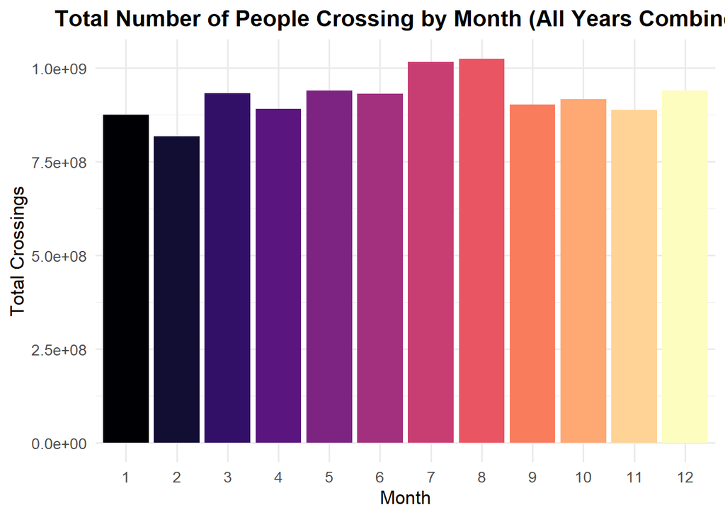

```r
library(tidyverse)
library(lubridate)

# make the plot
border <- border %>%
  filter(Year >= 1997, Year <= 2024, Value > 0) %>%
  mutate(Month = as.numeric(month))
monthly_total <- border %>%
  group_by(Month) %>%
  summarise(Total_Value = sum(Value, na.rm = TRUE)) %>%
  ungroup()
ggplot(monthly_total, aes(x = factor(Month), y = Total_Value, fill = factor(Month))) +
  geom_bar(stat = "identity", show.legend = FALSE) +
  scale_fill_viridis_d(option = "magma") +
  labs(
    title = "Total Number of People Crossing by Month (All Years Combined)",
    x = "Month",
    y = "Total Crossings"
  ) +
  theme_minimal(base_size = 13) +
  theme(
    plot.title = element_text(hjust = 0.5, face = "bold")
  )
```

```r
monthly_total_summary <- border %>%
  mutate(Month = as.numeric(month)) %>%
  group_by(Month) %>%
  summarise(Total_Value = sum(Value, na.rm = TRUE)) %>%
  arrange(desc(Total_Value)) %>%
  mutate(
    Month = month.abb[Month]  # Convert numeric month to abbreviation
  )

# --- Display with kable ---
monthly_total_summary %>%
  kable(
    caption = "Total Border Crossings by Month (All Years Combined, Arranged by Total)",
    col.names = c("Month", "Total Crossings"),
    format = "html",
    digits = 0,
    align = c("c", "r")
  ) %>%
  kable_styling(
    bootstrap_options = c("hover", "striped", "condensed"),
    full_width = FALSE,
    position = "center"
  ) %>%
  column_spec(1, bold = TRUE, color = "white", background = "#2c3e50") %>%
  column_spec(2, background = "#ecf0f1")
```

Total Border Crossings by Month (All Years Combined, Arranged by Total)

| Month | Total Crossings |
| --- | --- |
| Aug | 1025086302 |
| Jul | 1015854088 |
| May | 940016549 |
| Dec | 939890046 |
| Mar | 933149008 |
| Jun | 931327155 |
| Oct | 916677838 |
| Sep | 902578334 |
| Apr | 890693518 |
| Nov | 888566337 |
| Jan | 875550914 |
| Feb | 817849172 |

It could be seen that August has the most people to cross the board and Febrary has the least to people to cross, but there is no distinct difference between each month like the number of travelers all over the world distribute. For further study the relationship between different measure and month may could be processed.

5.conclusion In order to know the border crossing condition of recent 30 years, I use the data from the Bureau of Transprtation websites to do some analysis and visualization. The location,measure to cross, time and value could serve as key variables to analysis the relationship between them, there several changes in the value for each boarding location throught the year and there are also some measure and value difference between Maxico and Canada border that show the trend of this two borders. But doubtly, the crossing people did not show any trend like travellers did in month distribution so further reasearch of each measure might could be done.